# Time Series Analysis Method Summary(2)

Time Series

Time Series Analysis Method Summary

Yeongeun Jeon , Jung In Seo  
10-02-2021

- Data 출처 : [Data Mining for Business Analytics](https://www.dataminingbook.com/book/r-edition)에서 사용한 미국 철도 회사 “Amtrak”에서 수집한 1991년 1월~2004년 3월까지 매달 환승 고객 수

# **Data 불러오기**

```
pacman::p_load( "dplyr", "xts",
                "forecast", "dlm", "bsts",
                "caret", "caretEnsemble",
                "ggplot2")

library(doParallel)
library(parallel)

# cl <- makePSOCKcluster(detectCores())
# clusterEvalQ(cl, library(foreach))
# registerDoParallel(cores=cl)

registerDoParallel(cores=detectCores())


# Data 불러오기 ----------------------------------------------------------------

# In Mac
# guess_encoding("Amtrak.csv")
# Amtrak.data <- read.csv("Amtrak.csv", fileEncoding="EUC-KR")

Amtrak.data <- read.csv("C:/Users/User/Desktop/Amtrak.csv")
Amtrak.data$Month <- as.Date(Amtrak.data$Month, format = "%d/%m/%Y")               # For ggplot
ridership.ts <- ts(Amtrak.data$Ridership, start=c(1991,1), end=c(2004,3), freq=12)
```

# **Data 분할**

```
train.ts     <- window(ridership.ts,start=c(1991,1), end=c(2001,3))   # Training Data
test.ts      <- window(ridership.ts,start=c(2001,4))                  # Test Data
n.test       <- length(test.ts)
```

# **예측 변수 생성**

[output not shown]

[output not shown]

[output cut: 105 more lines]

[output not shown]

[output not shown]

# **전통적 시계열 모형**

- 전통적인 방법으로 사용될 모형은 다음과 같다.
  - Regression with ARIMA error
  - Dynamic Linear Model
  - Bootstrap and Bagging
  - Dynamic Harmonic Model
  - STLM
  - Baysian Structural Time Series Model
  - TBATS

## **1. Regression with ARIMA error**

- `forecast` package에 있는 `tslm()` 함수를 이용하여 추세와 계절성이 동시에 존재하는 회귀모형을 적합시켜보았다.
- 추세는 U자형으로 2차함수 형태의 추세를 고려하였다.

### **모형 적합**

```
# Fit Trend + Seasonality Model
train.lm.trend.season <- tslm(train.ts ~ trend + I(trend^2) + season)
summary(train.lm.trend.season)
```

```
Call:
tslm(formula = train.ts ~ trend + I(trend^2) + season)

Residuals:
     Min       1Q   Median       3Q      Max
-213.775  -39.363    9.711   42.422  152.187

Coefficients:
              Estimate Std. Error t value Pr(>|t|)
(Intercept)  1.697e+03  2.768e+01  61.318  < 2e-16 ***
trend       -7.156e+00  7.293e-01  -9.812  < 2e-16 ***
I(trend^2)   6.074e-02  5.698e-03  10.660  < 2e-16 ***
season2     -4.325e+01  3.024e+01  -1.430  0.15556
season3      2.600e+02  3.024e+01   8.598 6.60e-14 ***
season4      2.606e+02  3.102e+01   8.401 1.83e-13 ***
season5      2.938e+02  3.102e+01   9.471 6.89e-16 ***
season6      2.490e+02  3.102e+01   8.026 1.26e-12 ***
season7      3.606e+02  3.102e+01  11.626  < 2e-16 ***
season8      4.117e+02  3.102e+01  13.270  < 2e-16 ***
season9      9.032e+01  3.102e+01   2.911  0.00437 **
season10     2.146e+02  3.102e+01   6.917 3.29e-10 ***
season11     2.057e+02  3.103e+01   6.629 1.34e-09 ***
season12     2.429e+02  3.103e+01   7.829 3.44e-12 ***
---
Signif. codes:  0 '***' 0.001 '**' 0.01 '*' 0.05 '.' 0.1 ' ' 1

Residual standard error: 70.92 on 109 degrees of freedom
Multiple R-squared:  0.8246,    Adjusted R-squared:  0.8037
F-statistic: 39.42 on 13 and 109 DF,  p-value: < 2.2e-16
```

```
# Forecast
train.lm.trend.season.pred <- forecast(train.lm.trend.season, h=n.test, level=0)
train.lm.trend.season.pred
```

```
         Point Forecast     Lo 0     Hi 0
Apr 2001       2004.271 2004.271 2004.271
May 2001       2045.419 2045.419 2045.419
Jun 2001       2008.675 2008.675 2008.675
Jul 2001       2128.560 2128.560 2128.560
Aug 2001       2187.911 2187.911 2187.911
Sep 2001       1875.032 1875.032 1875.032
Oct 2001       2007.896 2007.896 2007.896
Nov 2001       2007.662 2007.662 2007.662
Dec 2001       2053.740 2053.740 2053.740
Jan 2002       1819.752 1819.752 1819.752
Feb 2002       1785.569 1785.569 1785.569
Mar 2002       2098.014 2098.014 2098.014
Apr 2002       2107.922 2107.922 2107.922
May 2002       2150.528 2150.528 2150.528
Jun 2002       2115.242 2115.242 2115.242
Jul 2002       2236.585 2236.585 2236.585
Aug 2002       2297.394 2297.394 2297.394
Sep 2002       1985.972 1985.972 1985.972
Oct 2002       2120.294 2120.294 2120.294
Nov 2002       2121.518 2121.518 2121.518
Dec 2002       2169.054 2169.054 2169.054
Jan 2003       1936.523 1936.523 1936.523
Feb 2003       1903.798 1903.798 1903.798
Mar 2003       2217.701 2217.701 2217.701
Apr 2003       2229.067 2229.067 2229.067
May 2003       2273.131 2273.131 2273.131
Jun 2003       2239.303 2239.303 2239.303
Jul 2003       2362.104 2362.104 2362.104
Aug 2003       2424.371 2424.371 2424.371
Sep 2003       2114.406 2114.406 2114.406
Oct 2003       2250.186 2250.186 2250.186
Nov 2003       2252.868 2252.868 2252.868
Dec 2003       2301.862 2301.862 2301.862
Jan 2004       2070.789 2070.789 2070.789
Feb 2004       2039.522 2039.522 2039.522
Mar 2004       2354.883 2354.883 2354.883
```

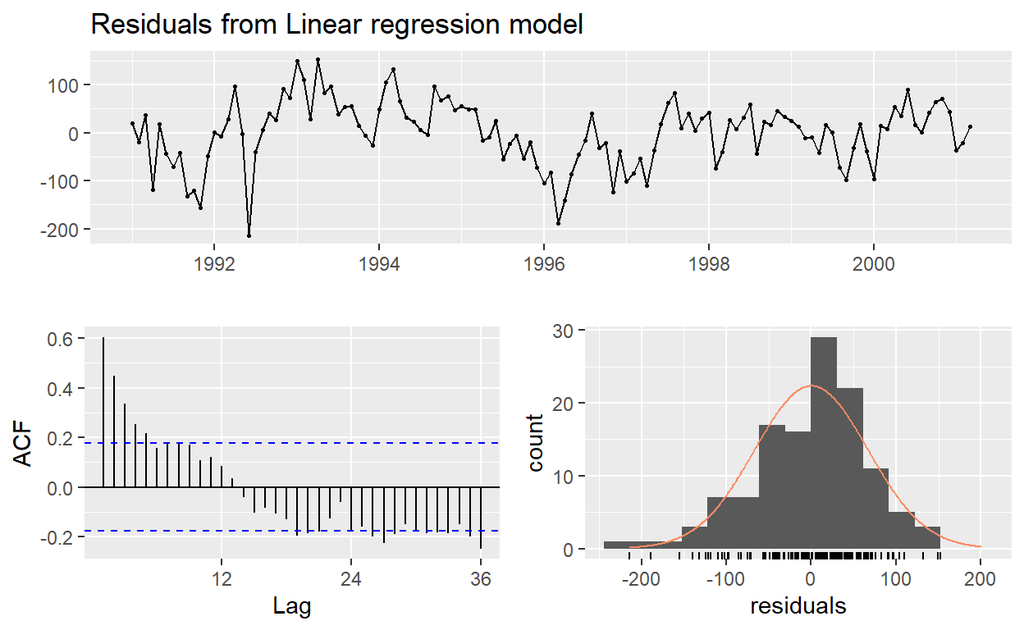

```
    Breusch-Godfrey test for serial correlation of order up to 24

data:  Residuals from Linear regression model
LM test = 57.142, df = 24, p-value = 0.0001599
```

```
checkresiduals(train.lm.trend.season)
```

- 모형 적합 후 잔차의 자기상관 그래프를 보면 잔차들이 독립이 아닌 것을 볼 수 있다.
  - 잔차는 white noise로써 독립을 만족해야한다.
- 정상성 시계열로 데이터를 변형하는 것보다 잔차에 회귀모형을 적합시키는 것은 데이터 변형을 필요로 하지 않는다.
- `잔차에 회귀모형을 적합`시킴으로써 예측값을 향상시킬 수 있다.
  - 짧은 기간의 예측에 유용하다.

```
# Fit ARIMA Model to training residuals
train.res.arima <- auto.arima(train.lm.trend.season$residuals)
summary(train.res.arima)
```

```
Series: train.lm.trend.season$residuals
ARIMA(1,0,1) with zero mean

Coefficients:
         ar1      ma1
      0.7416  -0.2286
s.e.  0.0972   0.1448

sigma^2 estimated as 2822:  log likelihood=-662.39
AIC=1330.77   AICc=1330.97   BIC=1339.21

Training set error measures:
                      ME     RMSE      MAE      MPE     MAPE
Training set -0.01267266 52.68668 40.29069 131.2931 202.8981
                  MASE        ACF1
Training set 0.5787867 0.005531221
```

```
train.res.arima.pred <- forecast(train.res.arima, h=n.test, level=0)
train.res.arima.pred$mean
```

```
              Jan          Feb          Mar          Apr          May
2001                                        3.090696e+00 2.292185e+00
2002 2.097959e-01 1.555931e-01 1.153941e-01 8.558095e-02 6.347029e-02
2003 5.809218e-03 4.308351e-03 3.195248e-03 2.369725e-03 1.757484e-03
2004 1.608565e-04 1.192977e-04 8.847596e-05
              Jun          Jul          Aug          Sep          Oct
2001 1.699977e+00 1.260772e+00 9.350394e-01 6.934630e-01 5.143002e-01
2002 4.707214e-02 3.491060e-02 2.589111e-02 1.920190e-02 1.424090e-02
2003 1.303421e-03 9.666697e-04 7.169213e-04 5.316978e-04 3.943286e-04
2004
              Nov          Dec
2001 3.814258e-01 2.828808e-01
2002 1.056163e-02 7.832931e-03
2003 2.924501e-04 2.168928e-04
2004
```

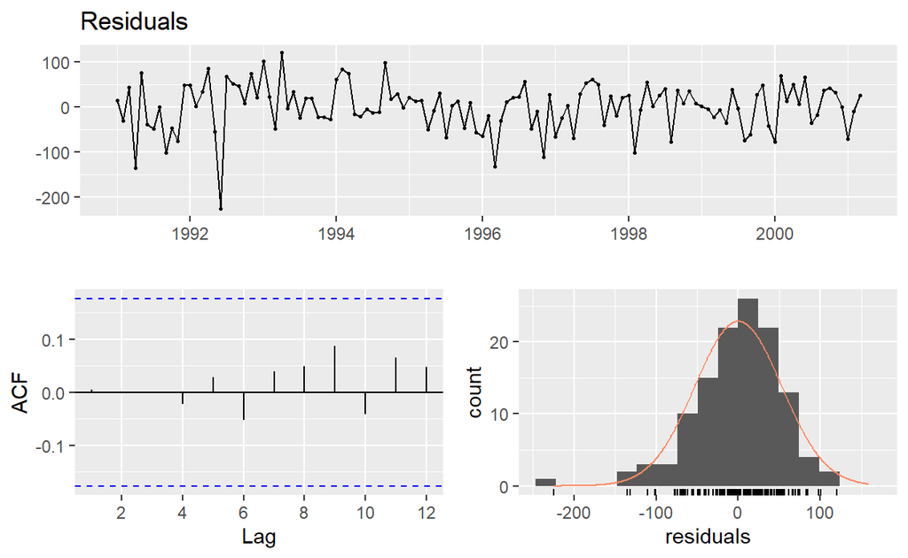

```
checkresiduals(train.res.arima$residuals, lag.max = 12)   # Uncorrelated.
```

### **예측**

[output not shown]

```
 [1] 2007.362 2047.712 2010.375 2129.821 2188.846 1875.725 2008.410
 [8] 2008.043 2054.023 1819.961 1785.724 2098.129 2108.008 2150.592
[15] 2115.289 2236.620 2297.420 1985.991 2120.308 2121.528 2169.061
[22] 1936.529 1903.802 2217.704 2229.070 2273.133 2239.304 2362.105
[29] 2424.371 2114.407 2250.187 2252.868 2301.862 2070.790 2039.522
[36] 2354.883
```

### **Accuracy**

```
Improved_forecast <- ts(Improved_forecast, start=c(2001,4), end=c(2004,3), freq=12)  # Convert as time-series

# Accuracy
acc.Regression <- accuracy(Improved_forecast, test.ts)
acc.Regression
```

```
                ME     RMSE     MAE       MPE     MAPE      ACF1
Test set -126.4976 153.2637 131.651 -6.447937 6.695432 0.7054902
         Theil's U
Test set 0.8962032
```

### **예측 그래프**

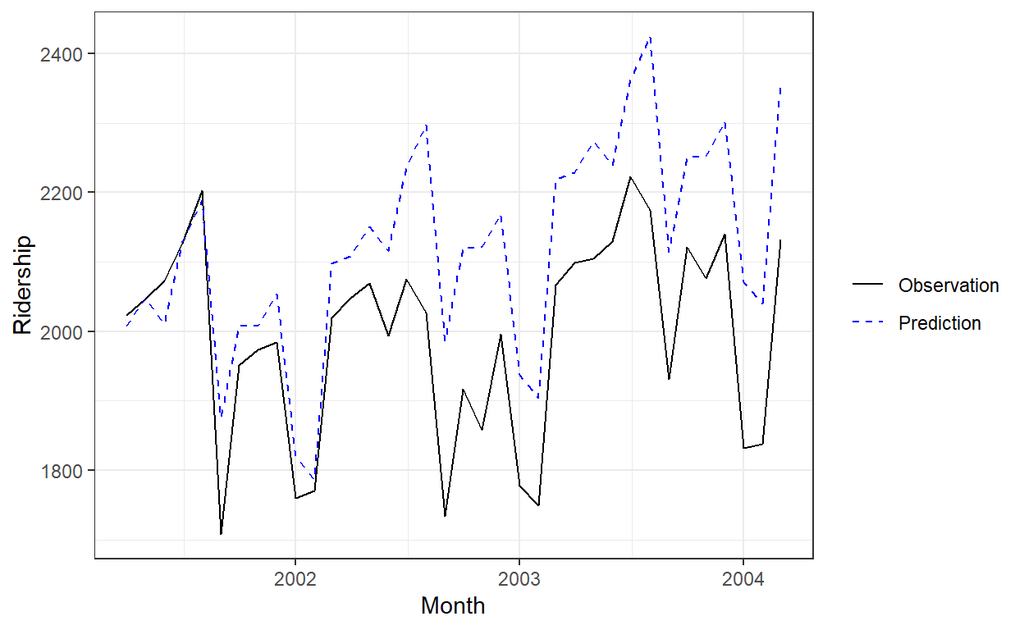

```
# Prediction Plot
ggplot(tail(Amtrak.data, n.test), aes(x = Month)) +
  geom_line(aes(y = Ridership, colour = "Observation", linetype = "Observation")) +
  geom_line(aes(y = Improved_forecast, colour = "Prediction", linetype = "Prediction")) +
  scale_color_manual(name = "", values = c("Observation" = "black", "Prediction" = "blue")) +
  scale_linetype_manual("", values = c("Observation"= 1, "Prediction" = 2)) +
  theme_bw()
```

## **2. Dynamic Linear Model**

- `dlm` package 안에 있는 여러 함수들을 이용하여 추정과 예측을 실시할 수 있다.
- DLM은 상태공간모형의 종류로, 선형성과 정규성을 가정하고 있다.
- DLM은 시간에 따라 변화하는 회귀계수를 가지는 선형회귀모형의 일반화 형태이다.

### **모형 적합**

```
# Fit Dynamic linear model (DLM)
DLM.model <- function(p){

  mod <- dlmModPoly(2) +  # local trend linear
    dlmModSeas(12)

  V(mod)            <- exp(p[1])
  diag(W(mod))[1:3] <- exp(p[2:4])

  return(mod)
}

mle1 <- dlmMLE(train.ts, parm = c(0.1,0.1,1,1), build = DLM.model )        # Estimation parameter through MLE. Parameter= Variance of error
ifelse(mle1$convergence==0, print("converge"), print("did not converge") ) # Check Convergence
```

```
[1] "converge"
```

```
[1] "converge"
```

```
DLM.model.fit <- DLM.model(mle1$par)  # Fitting the DLM
V(DLM.model.fit)
```

```
        [,1]
[1,] 1413.91
```

```
W(DLM.model.fit)
```

```
          [,1]      [,2]     [,3] [,4] [,5] [,6] [,7] [,8] [,9] [,10]
 [1,] 1143.988 0.0000000  0.00000    0    0    0    0    0    0     0
 [2,]    0.000 0.2040261  0.00000    0    0    0    0    0    0     0
 [3,]    0.000 0.0000000 14.47867    0    0    0    0    0    0     0
 [4,]    0.000 0.0000000  0.00000    0    0    0    0    0    0     0
 [5,]    0.000 0.0000000  0.00000    0    0    0    0    0    0     0
 [6,]    0.000 0.0000000  0.00000    0    0    0    0    0    0     0
 [7,]    0.000 0.0000000  0.00000    0    0    0    0    0    0     0
 [8,]    0.000 0.0000000  0.00000    0    0    0    0    0    0     0
 [9,]    0.000 0.0000000  0.00000    0    0    0    0    0    0     0
[10,]    0.000 0.0000000  0.00000    0    0    0    0    0    0     0
[11,]    0.000 0.0000000  0.00000    0    0    0    0    0    0     0
[12,]    0.000 0.0000000  0.00000    0    0    0    0    0    0     0
[13,]    0.000 0.0000000  0.00000    0    0    0    0    0    0     0
      [,11] [,12] [,13]
 [1,]     0     0     0
 [2,]     0     0     0
 [3,]     0     0     0
 [4,]     0     0     0
 [5,]     0     0     0
 [6,]     0     0     0
 [7,]     0     0     0
 [8,]     0     0     0
 [9,]     0     0     0
[10,]     0     0     0
[11,]     0     0     0
[12,]     0     0     0
[13,]     0     0     0
```

### **상태 추정**

- 관측되지 않은 상태 (예: 추세, 계절성)를 추정하기 위해 Kalman Filtering 방법을 사용하였다.

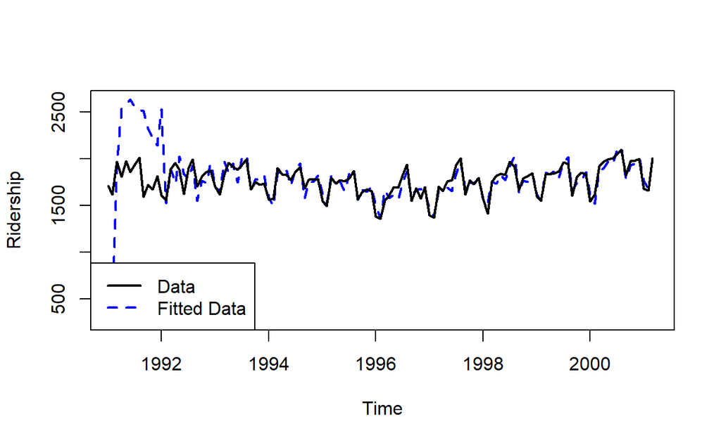

```
# Estimation for Kalman filtering
filtering <- dlmFilter(train.ts, DLM.model.fit)

# Plot estimation for filtering model
plot(dropFirst(filtering$f), col = "blue", lwd = 2, lty = 2, ylab = "Ridership")
lines(train.ts ,lty = 1, lwd = 2, col = "black")
legend("bottomleft", legend = c("Data", "Fitted Data"), col = c("black", "blue"), lty = 1:2, lwd = 2)
```

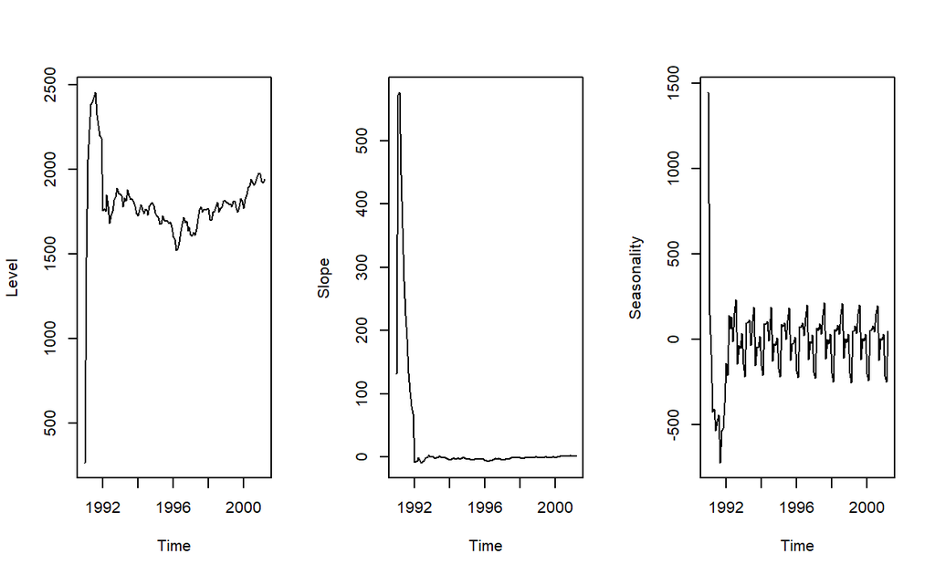

```
# Plot for estimated states
par(mfrow=c(1,3))
plot(dropFirst(filtering$m[,1]), ylab = "Level")
plot(dropFirst(filtering$m[,2]), ylab = "Slope")
plot(dropFirst(filtering$m[,3]), ylab = "Seasonality")
```

### **정규성 확인**

- DLM은 정규성을 가정하기 때문에 오차에 대해 정규성 확인이 필요하다.

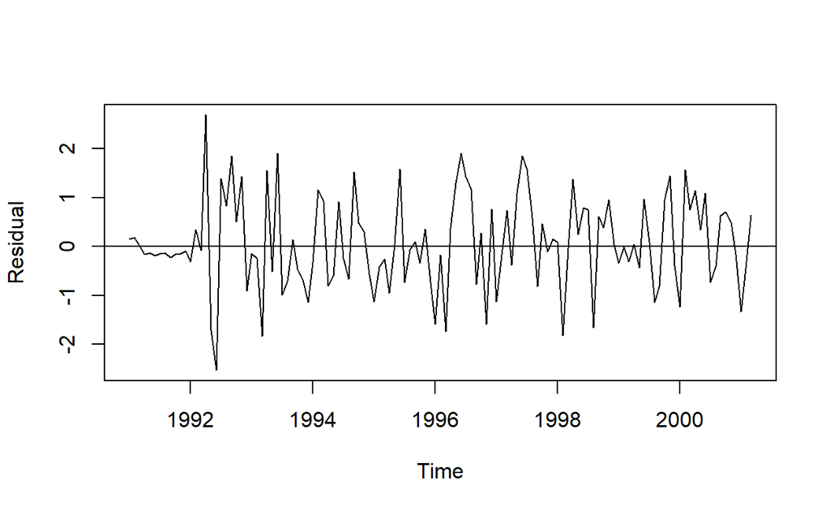

```
# Residual(Check independence and normality)
par(mfrow=c(1,1))
plot(residuals(filtering, sd = FALSE), ylab="Residual")
abline(h=0)
```

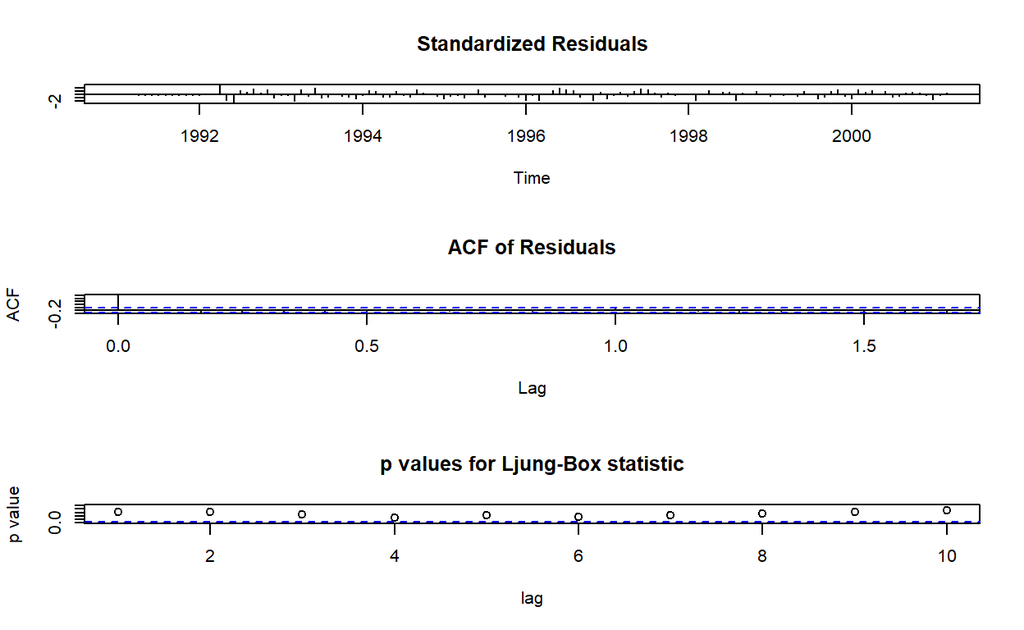

```
tsdiag(filtering, main = "Diagnostics for Regression Model")
```

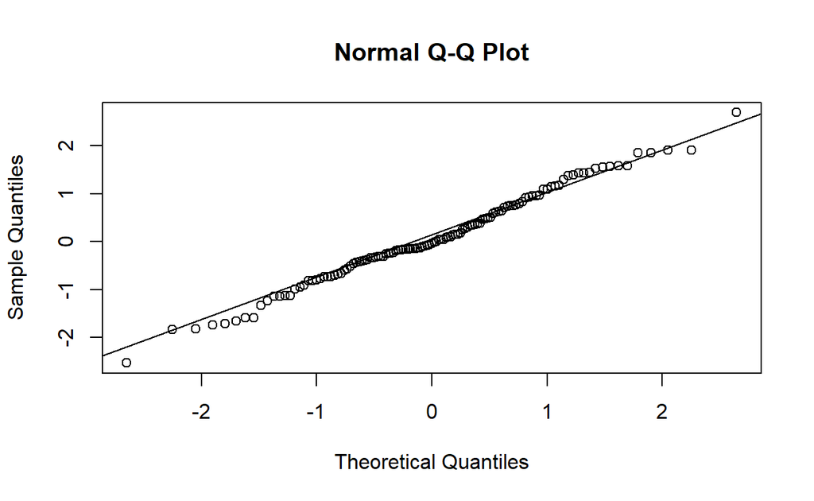

```
# Check normality for error
qqnorm(residuals(filtering, sd = FALSE))
qqline(residuals(filtering, sd = FALSE))
```

### **예측**

```
# Forecast
forecast_DLM <- dlmForecast(filtering, nAhead = n.test)  # Forecast(filtering model)
forecast_DLM$f
```

```
          Jan      Feb      Mar      Apr      May      Jun      Jul
2001                            1996.881 2024.378 1992.103 2100.250
2002 1743.912 1710.032 2013.061 2016.583 2044.080 2011.805 2119.952
2003 1763.614 1729.734 2032.762 2036.285 2063.782 2031.507 2139.654
2004 1783.316 1749.436 2052.464
          Aug      Sep      Oct      Nov      Dec
2001 2148.355 1830.904 1959.455 1953.408 1993.073
2002 2168.057 1850.606 1979.157 1973.110 2012.775
2003 2187.759 1870.308 1998.859 1992.812 2032.477
2004
```

### **Accuracy**

```
# Accuracy
acc.DLM <- accuracy(forecast_DLM$f, test.ts)
acc.DLM
```

```
               ME     RMSE      MAE       MPE     MAPE      ACF1
Test set 18.02393 67.51251 55.10431 0.8020044 2.784397 0.5948375
         Theil's U
Test set 0.3893913
```

### **예측 그래프**

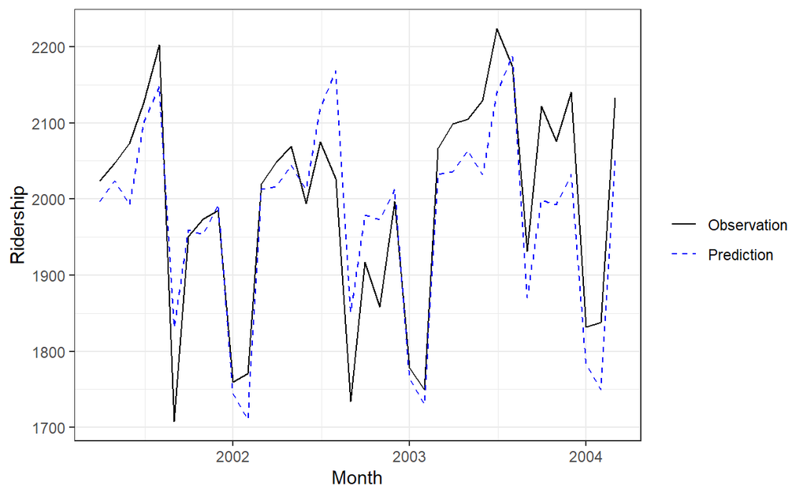

```
# Prediction Plot
ggplot(tail(Amtrak.data, n.test), aes(x = Month)) +
  geom_line(aes(y = Ridership, colour = "Observation", linetype = "Observation")) +
  geom_line(aes(y = forecast_DLM$f, colour = "Prediction", linetype = "Prediction")) +
  scale_color_manual(name = "", values = c("Observation" = "black", "Prediction" = "blue")) +
  scale_linetype_manual("", values = c("Observation"= 1, "Prediction" = 2)) +
  theme_bw()
```

## **3. Bootstrap and Bagging**

- 붓스트랩과 Bagging 방법을 이용하여 시계열 데이터를 추정하고 예측한다.
- 붓스트랩과 Bagging 방법의 가장 큰 핵심은 예측구간을 만들 수 있다는 것과 bagging을 이용하여 점 예측을 향상시킬 수 있다는 것이다.

### **모형 적합**

```
set.seed(100)
bagged <- train.ts %>%
  baggedModel(bld.mbb.bootstrap(train.ts, 100),fn = auto.arima)   # Generate 100set Bootstrap Samples and Fitting auto.arima for Each Bootstrap Sample Set
```

### **예측**

```
# Forecast
forecast_bagged <- bagged %>%
  forecast(h = n.test)  # Auto.arima is more accurate than ets. / Forecaste Each Fitted ARIMA Model by bootstrap sample set. Then, Calculate Mean
forecast_bagged$mean
```

```
          Jan      Feb      Mar      Apr      May      Jun      Jul
2001                            2007.388 2043.424 2002.164 2114.229
2002 1782.007 1738.522 2047.303 2048.708 2083.499 2041.520 2153.640
2003 1823.123 1779.574 2090.513 2092.330 2127.087 2085.660 2198.148
2004 1868.835 1825.044 2135.085
          Aug      Sep      Oct      Nov      Dec
2001 2162.860 1847.796 1980.844 1973.089 2012.932
2002 2203.439 1888.618 2021.920 2014.610 2055.572
2003 2248.026 1933.322 2065.527 2059.721 2100.603
2004
```

### **Accuracy**

```
# Accuracy
acc.Bagging <- accuracy(forecast_bagged$mean, test.ts)
acc.Bagging
```

```
                ME   RMSE      MAE       MPE     MAPE     ACF1
Test set -25.03095 64.975 45.95837 -1.365154 2.373141 0.507273
         Theil's U
Test set 0.3768781
```

### **예측 그래프**

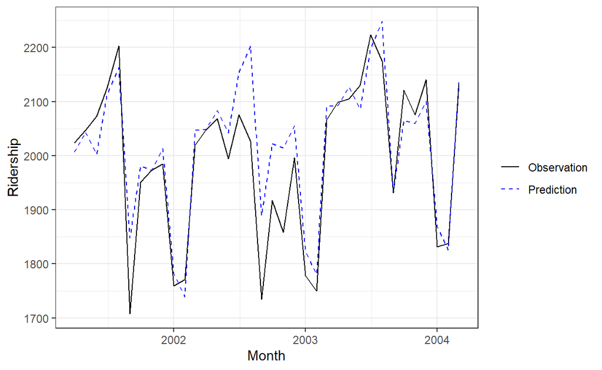

```
# Prediction Plot
ggplot(tail(Amtrak.data, n.test), aes(x = Month)) +
  geom_line(aes(y = Ridership, colour = "Observation", linetype = "Observation")) +
  geom_line(aes(y = forecast_bagged$mean, colour = "Prediction", linetype = "Prediction")) +
  scale_color_manual(name = "", values = c("Observation" = "black", "Prediction" = "blue")) +
  scale_linetype_manual("", values = c("Observation"= 1, "Prediction" = 2)) +
  theme_bw()
```

## **4. Dynamic Harmonic Model**

- `계절 주기가 길 때`, 계절성 ARIMA보다 선호되는 모델이 `Dynamic Harmonic Regression (DHR)`이다.
- DHR은 sine과 cosine 함수의 선형 조합으로써 `계절성을 설명하는 퓨리에 항(Fourier Terms)`을 가진 회귀 모형이다.

### **모형 적합**

```
DHR.fit <- auto.arima(train.ts,
                      xreg = as.matrix(Train.X),      # Include Fourier Terms
                      seasonal = FALSE)
DHR.fit
```

```
Series: train.ts
Regression with ARIMA(2,1,2) errors

Coefficients:
          ar1      ar2     ma1      ma2    Month     S1-12      C1-12
      -1.1998  -0.4967  0.2032  -0.4963  43.3345  109.4259  -150.3196
s.e.   0.1349   0.1294  0.1091   0.1353   9.2838   35.5583    12.9651
        S2-12     C2-12
      40.0290  -18.4092
s.e.  18.2969   12.3742

sigma^2 estimated as 9891:  log likelihood=-730.38
AIC=1480.76   AICc=1482.74   BIC=1508.8
```

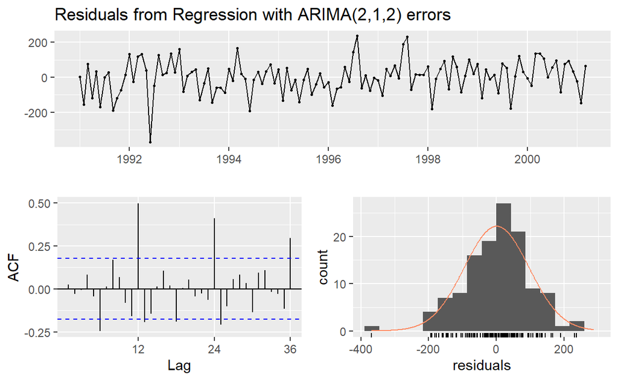

```
    Ljung-Box test

data:  Residuals from Regression with ARIMA(2,1,2) errors
Q* = 95.067, df = 15, p-value = 1.115e-13

Model df: 9.   Total lags used: 24
```

```
checkresiduals(DHR.fit)
```

### **예측**

```
# Forecast
DHR.forecast <- forecast(DHR.fit, xreg = as.matrix(Test.X))
DHR.forecast$mean
```

```
          Jan      Feb      Mar      Apr      May      Jun      Jul
2001                            1957.800 1980.577 2090.017 2020.626
2002 1651.827 1801.555 1912.521 1972.079 2010.833 2046.623 2057.661
2003 1647.319 1804.050 1911.767 1971.744 2011.609 2045.859 2058.193
2004 1647.258 1804.075 1911.768
          Aug      Sep      Oct      Nov      Dec
2001 2048.011 1943.821 1891.313 1907.054 1999.249
2002 2025.131 1952.878 1891.812 1901.957 2005.117
2003 2024.872 1952.924 1891.885 1901.846 2005.213
2004
```

### **Accuracy**

```
# Accuracy
acc.DHR <- accuracy(DHR.forecast$mean, test.ts)
acc.DHR
```

```
               ME     RMSE      MAE      MPE     MAPE       ACF1
Test set 58.24237 118.5707 97.03389 2.697112 4.885403 0.02801658
         Theil's U
Test set 0.6815818
```

### **예측 그래프**

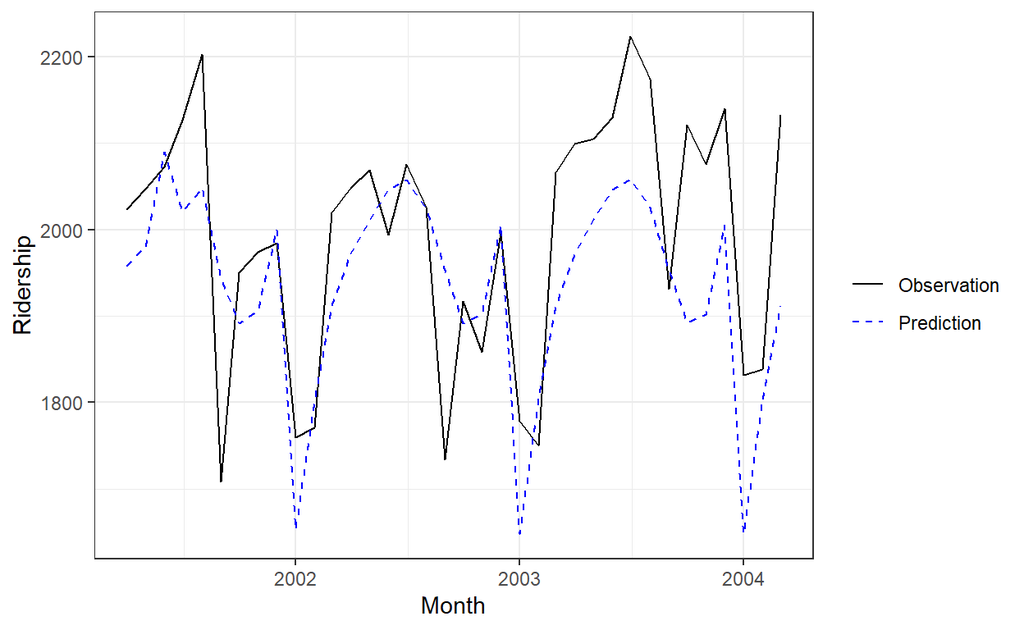

```
# Prediction Plot
ggplot(tail(Amtrak.data, n.test), aes(x = Month)) +
  geom_line(aes(y = Ridership, colour = "Observation", linetype = "Observation")) +
  geom_line(aes(y = DHR.forecast$mean, colour = "Prediction", linetype = "Prediction")) +
  scale_color_manual(name = "", values = c("Observation" = "black", "Prediction" = "blue")) +
  scale_linetype_manual("", values = c("Observation"= 1, "Prediction" = 2)) +
  theme_bw()
```

## **5. STLM**

- `STL (Seasonal and Trend decomposition using Loess)` 을 이용하여 시계열 데이터를 계절 성분(Seasonal Component)과 추세 + 오차 성분(Seasonally Adjusted Component)로 분해하고 각 성분을 따로 예측 후 더하여 최종 예측이 이루어진다.
- 계절 성분은 Seasonal naive method로, 추세 + 오차 성분은 시계열 모형으로 예측한다.

### **모형 적합**

[output not shown]

```
Series: x
Regression with ARIMA(0,1,1) errors

Coefficients:
          ma1   Month    S1-12   C1-12    S2-12    C2-12
      -0.4497  0.3528   6.5749  0.1468  -0.8428  -0.1513
s.e.   0.0958  2.2538  11.8652  8.6959   7.0494   6.1778

sigma^2 estimated as 2881:  log likelihood=-656.06
AIC=1326.11   AICc=1327.1   BIC=1345.74
```

### **예측**

[output not shown]

```
          Jan      Feb      Mar      Apr      May      Jun      Jul
2001                            1999.378 2030.771 2016.893 2115.862
2002 1722.372 1688.243 1990.391 1999.378 2030.771 2016.893 2115.862
2003 1722.372 1688.243 1990.391 1999.378 2030.771 2016.893 2115.862
2004 1722.372 1688.243 1990.391
          Aug      Sep      Oct      Nov      Dec
2001 2149.749 1831.360 1966.957 1959.655 1990.394
2002 2149.749 1831.360 1966.957 1959.655 1990.394
2003 2149.749 1831.360 1966.957 1959.655 1990.394
2004
```

### **Accuracy**

```
# Accuracy
acc.STLM <- accuracy(STLM.forecast$mean, test.ts)
acc.STLM
```

```
               ME     RMSE      MAE      MPE     MAPE     ACF1
Test set 38.04171 83.77231 70.30234 1.821433 3.555029 0.694755
         Theil's U
Test set 0.4885911
```

### **예측 그래프**

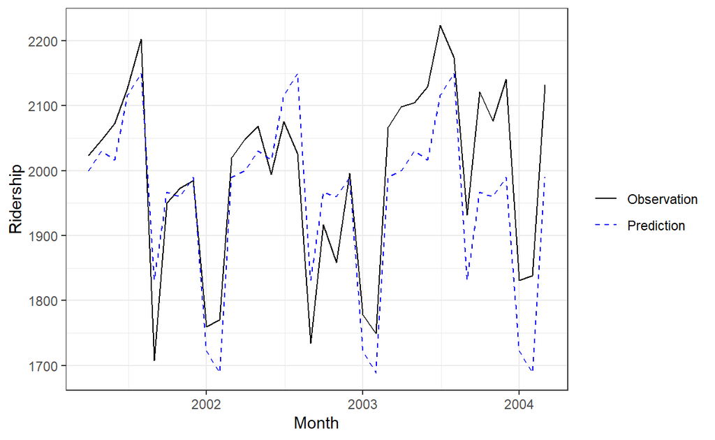

```
# Prediction Plot
ggplot(tail(Amtrak.data, n.test), aes(x = Month)) +
  geom_line(aes(y = Ridership, colour = "Observation", linetype = "Observation")) +
  geom_line(aes(y = STLM.forecast$mean, colour = "Prediction", linetype = "Prediction")) +
  scale_color_manual(name = "", values = c("Observation" = "black", "Prediction" = "blue")) +
  scale_linetype_manual("", values = c("Observation"= 1, "Prediction" = 2)) +
  theme_bw()
```

## **6. Baysian Structural Time Series Model**

- Bayesian Structural Time Series (BSTS)는 `Structural Time Seires (STS) 모형에 Bayesian 방법을 적용`하는 방법이다.
- BSTS는 R package `bsts`를 통해 다룰 수 있다.

### **모형 적합**

```
Train.Data <- data.frame("y"= train.ts, Train.X[,1])     # Excluding Fourier Terms

ss <- list()
# Local Linear Trend
ss <- bsts::AddLocalLinearTrend(ss, train.ts)
# Seasonal
ss <- bsts::AddSeasonal(ss, train.ts, nseasons = 12, season.duration = 1) # cycle = season.duration(how many time points each season) * nseasons

BSTS.fit <- bsts(y ~., state.specification = ss, data = Train.Data, niter = 1000, seed=100)  # niter : MCMC 반복복
```

[output not shown]

```
summary(BSTS.fit)
```

```
$residual.sd
[1] 38.38387

$prediction.sd
[1] 86.37815

$rsquare
[1] 0.9424972

$relative.gof
[1] 0.7358398

$size
   Min. 1st Qu.  Median    Mean 3rd Qu.    Max.
0.00000 0.00000 0.00000 0.07092 0.00000 1.00000

$coefficients
                  mean       sd mean.inc   sd.inc   inc.prob
Train.X...1. 0.1077952 0.539501 1.519912 1.414357 0.07092199
(Intercept)  0.0000000 0.000000 0.000000 0.000000 0.00000000
```

### **예측**

```
# Forecast
burn <- SuggestBurn(0.1, BSTS.fit)
BSTS.forecast <- predict(BSTS.fit, horizon = n.test,             # horizon : the number of prediction
                         burn = burn, newdata = Test.X[,1],      # newdata : 예측변수를 포함하는 변수
                         quantiles = c(0.025, 0.975))
BSTS.forecast$mean
```

```
 [1] 2008.649 2033.859 2005.471 2115.656 2159.608 1849.589 1985.606
 [8] 1980.895 2025.518 1771.432 1738.900 2042.580 2046.658 2077.231
[15] 2049.163 2155.931 2204.486 1889.507 2028.428 2029.719 2066.013
[22] 1816.823 1787.502 2091.551 2097.854 2122.777 2100.560 2208.762
[29] 2256.867 1945.645 2080.120 2076.238 2118.645 1870.599 1843.099
[36] 2145.638
```

### **Accuracy**

```
# Accuracy
acc.BSTS <- accuracy(BSTS.forecast$mean, test.ts)
acc.BSTS
```

```
                ME     RMSE      MAE       MPE     MAPE      ACF1
Test set -29.77804 66.58763 45.96603 -1.599523 2.379736 0.5265906
         Theil's U
Test set 0.3875899
```

### **예측 그래프**

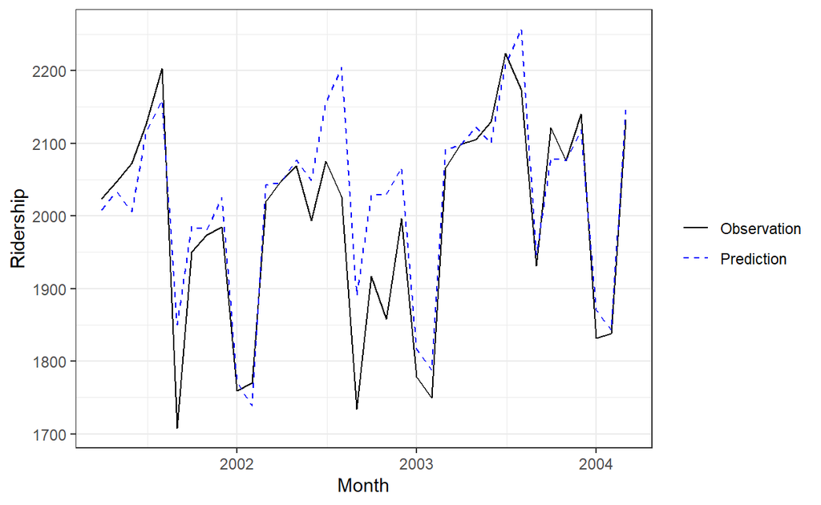

```
# Prediction Plot
ggplot(tail(Amtrak.data, n.test), aes(x = Month)) +
  geom_line(aes(y = Ridership, colour = "Observation", linetype = "Observation")) +
  geom_line(aes(y = BSTS.forecast$mean, colour = "Prediction", linetype = "Prediction")) +
  scale_color_manual(name = "", values = c("Observation" = "black", "Prediction" = "blue")) +
  scale_linetype_manual("", values = c("Observation"= 1, "Prediction" = 2)) +
  theme_bw()
```

## **7. TBATS**

- TBATS 모형은 `복잡한 계절성`을 가진 시계열 데이터를 분석하는 데 유용하다.
- TBATS 모형은 `광범위한 계절 패턴 변동`과 관련된 문제를 극복하고 `상관성이 있는 오차`를 처리하기 위해 `지수 평활(Exponential Smoothing)`을 사용한 수정된 상태공간 모형으로 [De Livera et al. (2011)](https://robjhyndman.com/papers/ComplexSeasonality.pdf)이 제안하였다

### **모형 적합**

```
cl <- parallel::makeCluster(detectCores(), setup_timeout = 0.5)
TBATS.fit <- train.ts %>%
  tbats(use.box.cox = FALSE,
        use.trend = TRUE,
        use.damped.trend = TRUE,
        use.parallel = TRUE,
        num.cores = cl)

summary(TBATS.fit)
```

```
                  Length Class  Mode
lambda               0   -none- NULL
alpha                1   -none- numeric
beta                 1   -none- numeric
damping.parameter    1   -none- numeric
gamma.one.values     1   -none- numeric
gamma.two.values     1   -none- numeric
ar.coefficients      0   -none- NULL
ma.coefficients      0   -none- NULL
likelihood           1   -none- numeric
optim.return.code    1   -none- numeric
variance             1   -none- numeric
AIC                  1   -none- numeric
parameters           2   -none- list
seed.states         12   -none- numeric
fitted.values      123   ts     numeric
errors             123   ts     numeric
x                 1476   -none- numeric
seasonal.periods     1   -none- numeric
k.vector             1   -none- numeric
y                  123   ts     numeric
p                    1   -none- numeric
q                    1   -none- numeric
call                 7   -none- call
series               1   -none- character
method               1   -none- character
```

### **예측**

```
# Forecast
TBATS.forecast <- forecast(TBATS.fit, h=n.test)
TBATS.forecast$mean
```

```
          Jan      Feb      Mar      Apr      May      Jun      Jul
2001                            1978.995 2028.484 1959.201 2089.790
2002 1721.923 1658.583 1979.689 1966.634 2018.589 1951.281 2083.449
2003 1720.255 1657.248 1978.620 1965.779 2017.904 1950.732 2083.010
2004 1720.140 1657.155 1978.546
          Aug      Sep      Oct      Nov      Dec
2001 2116.995 1814.845 1914.140 1924.798 1938.481
2002 2111.919 1810.782 1910.888 1922.195 1936.397
2003 2111.568 1810.501 1910.663 1922.015 1936.252
2004
```

### **Accuracy**

```
# Accuracy
acc.TBATS <- accuracy(TBATS.forecast$mean, test.ts)
acc.TBATS
```

```
               ME    RMSE      MAE      MPE    MAPE     ACF1
Test set 69.36452 103.114 88.31896 3.379683 4.42057 0.556916
         Theil's U
Test set 0.5999032
```

### **예측 그래프**

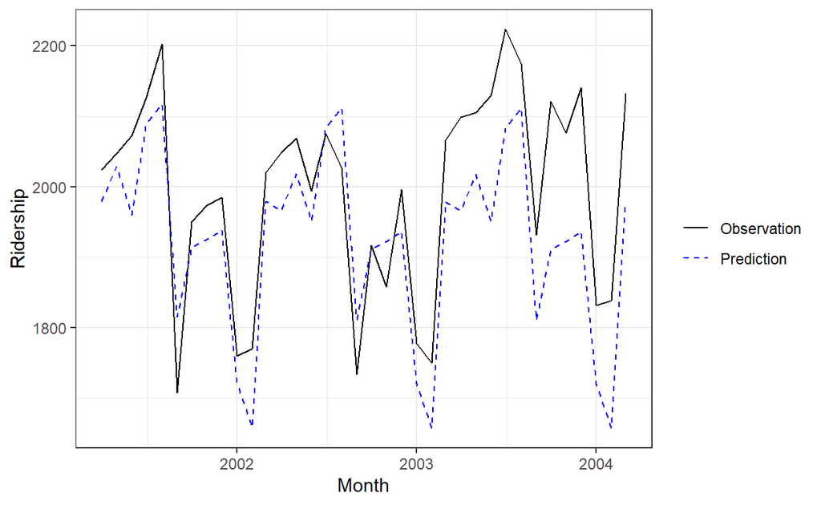

```
# Prediction Plot
ggplot(tail(Amtrak.data, n.test), aes(x = Month)) +
  geom_line(aes(y = Ridership, colour = "Observation", linetype = "Observation")) +
  geom_line(aes(y = TBATS.forecast$mean, colour = "Prediction", linetype = "Prediction")) +
  scale_color_manual(name = "", values = c("Observation" = "black", "Prediction" = "blue")) +
  scale_linetype_manual("", values = c("Observation"= 1, "Prediction" = 2)) +
  theme_bw()
```

## **예측 비교1**

### **Line Plot**

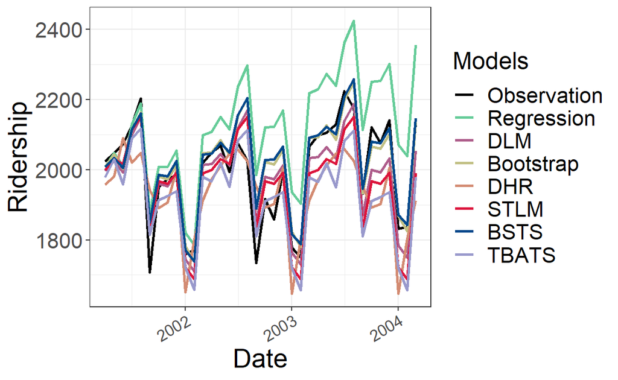

```
# 1. Line Plot
Pred.Data <- data.frame("Date" = tail(Amtrak.data$Month, n.test),
                        "Observation" = test.ts,
                        "Regression" = Improved_forecast,
                        "DLM" = c(forecast_DLM$f),
                        "Bootstrap" = forecast_bagged$mean,
                        "DHR" = DHR.forecast$mean,
                        "STLM" = STLM.forecast$mean,
                        "BSTS" = BSTS.forecast$mean,
                        "TBATS" = TBATS.forecast$mean)


Pred.Models <- reshape2::melt(Pred.Data, id.vars="Date",
                              variable.name="Type",
                              value.name='y')

models <- unique(Pred.Models$Type)

lcols <- c("#000000", "#66CC99", "#ae5d8b", "#c1c084", "#d38b72", "#dc143c", "#00498c", "#9999CC")

ggplot(Pred.Models, aes(x=Date, y=y, group=Type)) +
  geom_line(aes(color=Type), size=1, linetype="solid") +
  labs(x="Date", y="Ridership") +                # y="log(Charging demand)"
  scale_color_manual(values = lcols, name = 'Models', labels = models) +
  #scale_x_datetime(date_breaks= "24 hour", date_labels = paste("%Y- %m-%d %H", "h", sep="")) +  # %Y- %m-%d %H:%M:%S"
  theme_bw() +
  theme(axis.text.y=element_text(size=16),
        axis.title=element_text(size=20),
        axis.text.x=element_text(angle=30, hjust=1, size=12),
        legend.title = element_text(size=18),
        legend.text = element_text(size=16))
```

### **Scatter Plot**

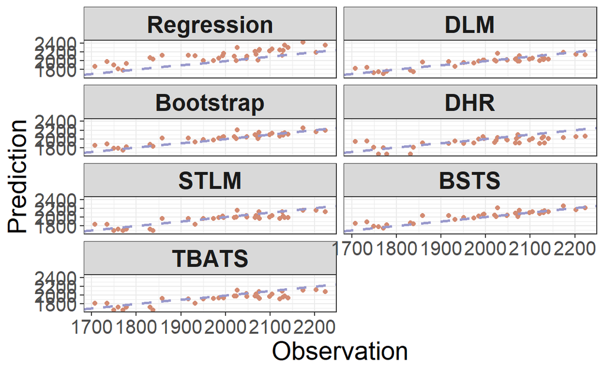

```
# 2. Scatter Plot
Pred.Models2 <- reshape2::melt(Pred.Data[,-1], id.vars="Observation",
                              variable.name="Type",
                              value.name='Pred')

ggplot(Pred.Models2, aes(x=Observation, y=Pred)) +
  geom_point(color="#d38b72") +
  geom_abline(intercept = 0, slope = 1, size=1, colour="#9999CC", linetype="dashed") +
  facet_wrap( ~ Type, ncol=2) +
  labs(x="Observation", y="Prediction", color = "") +
  theme_bw() +
  theme(axis.title=element_text(size=20),
        axis.text=element_text(size=15),
        strip.text.x = element_text(size=18, face="bold"))
```

# **머신 러닝 기법**

- 머신 러닝 기법에서 예제 데이터에 적용되는 기법은 다음과 같다.
  - Neural Network Model
  - Random Forest
  - XGBoost (eXtreme Gradient Boosting)

## **분해**

- 머신 러닝 기법 중 트리 기반 모델은 추세(Trend)를 포착하지 못하기 때문에, 추세를 제거한 Detrend Dataset에 머신 러닝 기법을 적용하고 추세는 따로 모델링을 해야한다.

[output not shown]

## **추세**

- 추세는 ARIMA 모형을 이용하여 예측하였다.

```
trend.part  <- data.frame(decomp.ts)$trend %>% # Only Trend of Training Data
  ts()

# Fitting ARIMA for Trend
trend.fit.arima   <- auto.arima(trend.part)

# Forecast
trend.arima.pred  <- forecast(trend.fit.arima, n.test)
trend.arima.pred$mean
```

```
Time Series:
Start = 124
End = 159
Frequency = 1
 [1] 1963.065 1966.790 1970.428 1974.067 1977.679 1981.291 1984.895
 [8] 1988.498 1992.099 1995.700 1999.301 2002.901 2006.501 2010.101
[15] 2013.701 2017.301 2020.901 2024.501 2028.101 2031.701 2035.301
[22] 2038.901 2042.501 2046.101 2049.701 2053.301 2056.901 2060.501
[29] 2064.101 2067.701 2071.301 2074.901 2078.501 2082.101 2085.701
[36] 2089.301
```

## **1. Neural Network Model**

- 시계열의 `시차값`이 `신경망의 입력값`으로써 사용될 수 있으며 이것을 신경망 자기회귀 또는 NNAR 모형이라고 부른다.
- NNAR($p,k$)는 출력값 $y_{t}$를 예측하기 위해 마지막 $p$개의 관측값 ($y_{t-1}$, $y_{t-2}$, $\ldots$, $y_{t-p}$)을 입력값으로 사용하고 숨겨진 계층에 $k$개의 뉴런이 있는 신경망이다.
- 계절성이 있는 경우 모형은 NNAR$(p,P,k)_{m}$로써 $P$는 입력값으로써 사용된 계절성 시차의 수이며 $m$은 주기를 의미한다.
  - NNAR$(p,P,k)_{m}$은 $y_{t-1}$, $\ldots$, $y_{t-p}$, $y_{t-m}$, $y_{t-2m}$, $\ldots$, $y_{t-mP}$를 입력값으로써 사용하고, 숨겨진 계층에 $k$개의 뉴런이 있다.

### **모형 적합**

```
set.seed(100)
neural_model <- nnetar(ts(Target, start=c(1991,1), end=c(2001,3), freq = 12),    # Or train.ts
                       xreg = Train.X,
                       repeats = 200,
                       lambda = "auto")

neural_model
```

```
Series: ts(Target, start = c(1991, 1), end = c(2001, 3), freq = 12)
Model:  NNAR(1,1,4)[12]
Call:   nnetar(y = ts(Target, start = c(1991, 1), end = c(2001, 3), freq = 12),
    repeats = 200, xreg = Train.X, lambda = "auto")

Average of 200 networks, each of which is
a 7-4-1 network with 37 weights
options were - linear output units

sigma^2 estimated as 2163
```

### **예측**

```
# Forecast for Detrended
forecast_neu <- forecast(neural_model, PI = TRUE,  # PI : Confidencd Interval
                         h = n.test,
                         xreg = Test.X,
                         npaths = 100, level = 95) # Npaths : How many simulation

# Final Prediction (Detrended + Trend)
NNAR.forecast <- c(forecast_neu$mean) + c(trend.arima.pred$mean)
```

### **Accuracy**

```
# Accuracy
acc.NNAR <- accuracy(NNAR.forecast, test.ts)
acc.NNAR
```

```
                ME     RMSE      MAE     MPE     MAPE      ACF1
Test set -30.87089 74.79254 47.02293 -1.6211 2.447256 0.5835289
         Theil's U
Test set 0.4346942
```

### **예측 그래프**

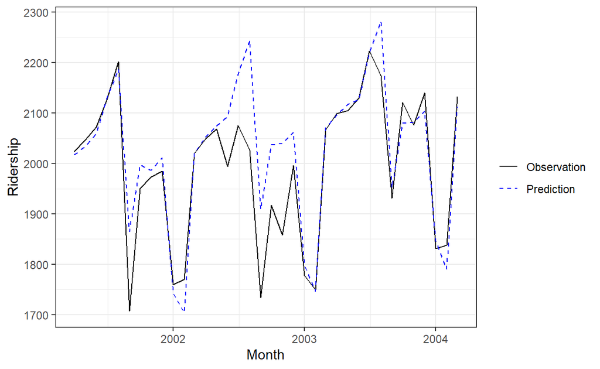

```
# Prediction Plot
ggplot(tail(Amtrak.data, n.test), aes(x = Month)) +
  geom_line(aes(y = Ridership, colour = "Observation", linetype = "Observation")) +
  geom_line(aes(y = NNAR.forecast, colour = "Prediction", linetype = "Prediction")) +
  scale_color_manual(name = "", values = c("Observation" = "black", "Prediction" = "blue")) +
  scale_linetype_manual("", values = c("Observation"= 1, "Prediction" = 2)) +
  theme_bw()
```

## **2. Random Forest**

- Bagging을 이용한 트리 기반 모형이다.
- 나무를 분할할 때 랜덤적으로 후보 예측 변수를 선택함으로써, 생성된 나무들의 연관성은 감소된다.
- Hyperparameter로 `mtry` (랜덤적으로 선택되는 후보 예측 변수 갯수)를 가진다.

### **모형 적합**

[output not shown]

```
Parallel Random Forest

123 samples
  5 predictor

No pre-processing
Resampling: Adaptively Cross-Validated (5 fold, repeated 5 times)
Summary of sample sizes: 99, 99, 97, 99, 98, 99, ...
Resampling results across tuning parameters:

  mtry  RMSE      Rsquared   MAE       Resamples
  1     52.87737  0.8892022  40.21114  25
  3     50.21355  0.8949560  38.53876  25

RMSE was used to select the optimal model using the smallest value.
The final value used for the model was mtry = 3.
```

```
RF.Caret$finalModel
```

```
Call:
 randomForest(x = "x", y = "y", ntree = 13, mtry = 3L, nodesize = 5,      importance = TRUE)
               Type of random forest: regression
                     Number of trees: 104
No. of variables tried at each split: 3
```

```
RF.Caret$finalModel$tuneValue
```

```
  mtry
2    3
```

### **예측**

```
# Final Prediction (Detrended + Trend)
Pred.RF <- predict(RF.Caret, Test.X) + trend.arima.pred$mean
```

### **Accuracy**

```
# Accuracy
acc_RF  <- accuracy(c(Pred.RF), test.ts)
acc_RF
```

```
                ME     RMSE      MAE       MPE     MAPE      ACF1
Test set -29.23913 71.90871 46.82079 -1.546831 2.423727 0.6008866
         Theil's U
Test set 0.4190109
```

### **예측 그래프**

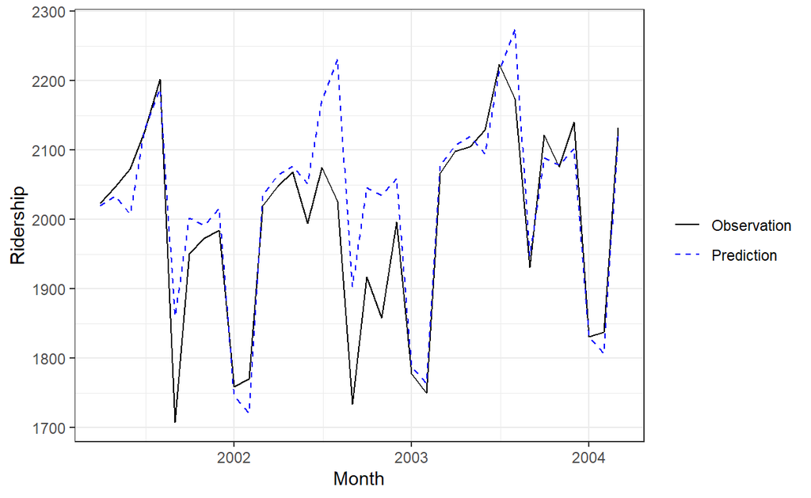

```
# Prediction Plot
ggplot(tail(Amtrak.data, n.test), aes(x = Month)) +
  geom_line(aes(y = Ridership, colour = "Observation", linetype = "Observation")) +
  geom_line(aes(y = Pred.RF, colour = "Prediction", linetype = "Prediction")) +
  scale_color_manual(name = "", values = c("Observation" = "black", "Prediction" = "blue")) +
  scale_linetype_manual("", values = c("Observation"= 1, "Prediction" = 2)) +
  theme_bw()
```

## **3. XGBoost**

- Boosting을 이용한 트리 기반 모형이다.
- 손실함수와 경사하강법을 이용하는 Gradient Boosting의 단점을 해결하기 위해 제안되었다.
- 가장 큰 특징으로는, 병렬 처리로 인해 빠르고 조기 종료가 가능하다는 것이다.
- XGBoost에서 Hyperparameter는 다음과 같다.
  - `nrounds` : 반복 수
  - `max_depth` : Tree의 최대 깊이
  - `eta` : Learning Late
  - `gamma` : 분할하기 위해 필요한 최소 손실 감소, 클수록 분할이 쉽게 일어나지 않음
  - `colsample_bytree` : Tree 생성 때 사용할 예측변수 비율
  - `min_child_weight` : 한 leaf 노드에 요구되는 관측치에 대한 가중치의 최소 합
  - `subsample` : 모델 구축시 사용할 Data비율로 1이면 전체 Data 사용

### **모형 적합**

```
set.seed(100)
fitControl <- trainControl(method = "adaptive_cv",   # cv, repeatedcv
                           number = 5,
                           repeats = 5,
                           adaptive = list(min = 5,
                                           alpha = 0.05,
                                           method = "BT",
                                           complete = TRUE),
                           search = "random",
                           allowParallel = TRUE)

XGBoost <- function(train, tuneLength){

  set.seed(100)                                         # seed 고정 For Cross Validation
  caret.xgb <- caret::train(y~., data = train,
                            method = "xgbTree",
                            trControl = fitControl,
                            # objective = "reg:squarederror", # error(The following parameters were provided multiple times)
                            tuneLength = tuneLength     # tuneLength (탐색할 후보 모수 갯수)
  )

  return(caret.xgb)

}

XGB.Caret <- XGBoost(Train.Data, 2)
XGB.Caret
```

```
eXtreme Gradient Boosting

123 samples
  5 predictor

No pre-processing
Resampling: Adaptively Cross-Validated (5 fold, repeated 5 times)
Summary of sample sizes: 99, 99, 97, 99, 98, 99, ...
Resampling results across tuning parameters:

  eta        max_depth  gamma     colsample_bytree  min_child_weight
  0.2228220  9          1.702621  0.6528662         3
  0.4876292  3          5.465586  0.5499986         5
  subsample  nrounds  RMSE      Rsquared   MAE       Resamples
  0.7517663  624      50.21422  0.8931412  38.60326  25
  0.8219133  358      50.06911  0.8961369  38.41744  25

RMSE was used to select the optimal model using the smallest value.
The final values used for the model were nrounds = 358, max_depth
 = 3, eta = 0.4876292, gamma = 5.465586, colsample_bytree
 = 0.5499986, min_child_weight = 5 and subsample = 0.8219133.
```

```
XGB.Caret$finalModel
```

```
##### xgb.Booster
raw: 181.9 Kb
call:
  xgboost::xgb.train(params = list(eta = param$eta, max_depth = param$max_depth,
    gamma = param$gamma, colsample_bytree = param$colsample_bytree,
    min_child_weight = param$min_child_weight, subsample = param$subsample),
    data = x, nrounds = param$nrounds, objective = "reg:linear")
params (as set within xgb.train):
  eta = "0.48762916797353", max_depth = "3", gamma = "5.46558595029637", colsample_bytree = "0.549998590815812", min_child_weight = "5", subsample = "0.82191331172362", objective = "reg:linear", silent = "1"
xgb.attributes:
  niter
callbacks:
  cb.print.evaluation(period = print_every_n)
# of features: 5
niter: 358
nfeatures : 5
xNames : Month `S1-12` `C1-12` `S2-12` `C2-12`
problemType : Regression
tuneValue :
      nrounds max_depth       eta    gamma colsample_bytree
2     358         3 0.4876292 5.465586        0.5499986
  min_child_weight subsample
2                5 0.8219133
obsLevels : NA
param :
    list()
```

```
XGB.Caret$finalModel$tuneValue
```

```
  nrounds max_depth       eta    gamma colsample_bytree
2     358         3 0.4876292 5.465586        0.5499986
  min_child_weight subsample
2                5 0.8219133
```

### **예측**

```
# Final Prediction (Detrended + Trend)
Pred.XGB  <- predict(XGB.Caret, Test.X) + trend.arima.pred$mean
```

### **Accuracy**

```
# Accuracy
acc_XGB   <- accuracy(c(Pred.XGB), test.ts)
acc_XGB
```

```
                ME     RMSE      MAE       MPE     MAPE      ACF1
Test set -27.27012 68.20048 47.95543 -1.475506 2.477208 0.5023489
         Theil's U
Test set 0.3950394
```

### **예측 그래프**

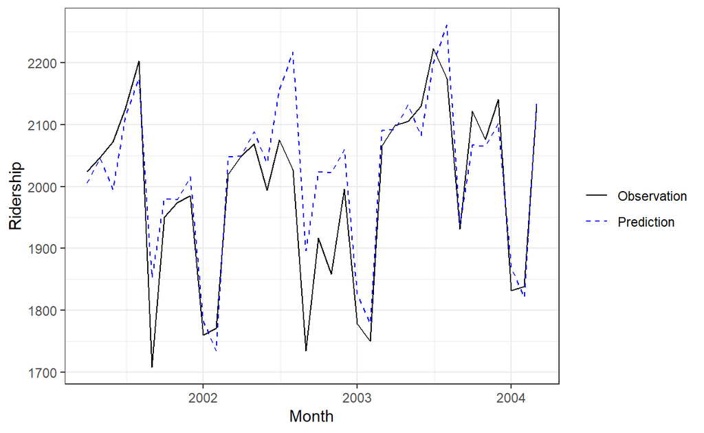

```
# Prediction Plot
ggplot(tail(Amtrak.data, n.test), aes(x = Month)) +
  geom_line(aes(y = Ridership, colour = "Observation", linetype = "Observation")) +
  geom_line(aes(y = Pred.XGB, colour = "Prediction", linetype = "Prediction")) +
  scale_color_manual(name = "", values = c("Observation" = "black", "Prediction" = "blue")) +
  scale_linetype_manual("", values = c("Observation"= 1, "Prediction" = 2)) +
  theme_bw()
```

## **4. Stacking**

- 앙상블의 종류 중 하나로, 개별적인 알고리즘을 통해 생성된 예측 결과들로 새로운 Training Dataset을 만들어 최종 모형을 적합시킨다.

### **모형 적합**

[output not shown]

```
Parallel Random Forest

123 samples
  5 predictor

No pre-processing
Resampling: Cross-Validated (5 fold, repeated 5 times)
Summary of sample sizes: 123
Resampling results:

  RMSE      Rsquared   MAE
  55.73908  0.8368916  42.4932

Tuning parameter 'mtry' was held constant at a value of 3
```

```
multi_mod$xgbTree
```

[output not shown]

```
# 2. Stacking (개별 모형들의 예측값을 결합한 Data를 Training data로 쓰는 Final Model))

set.seed(100)
stackControl <- trainControl(method = "adaptive_cv",
                             number = 5,
                             repeats = 5,
                             adaptive = list(min = 5,
                                             alpha = 0.05,
                                             method = "BT",
                                             complete = TRUE),
                             search = "random",
                             allowParallel = TRUE)

set.seed(100)
stack.xgb <- caretStack(multi_mod, method = "xgbTree",  # Final Model
                        trControl = stackControl,
                        tuneLength = 2)                 # 모수 후보 갯수수

stack.xgb
```

```
A xgbTree ensemble of 2 base models: parRF, xgbTree

Ensemble results:
eXtreme Gradient Boosting

38 samples
 2 predictor

No pre-processing
Resampling: Adaptively Cross-Validated (5 fold, repeated 5 times)
Summary of sample sizes: 30, 31, 31, 30, 30, 30, ...
Resampling results across tuning parameters:

  eta        max_depth  gamma     colsample_bytree  min_child_weight
  0.2228220  9          1.702621  0.6528662         3
  0.4876292  3          5.465586  0.5499986         5
  subsample  nrounds  RMSE      Rsquared  MAE       Resamples
  0.7517663  624      48.62987  0.929678  38.75318  25
  0.8219133  358      57.27670  0.924131  43.13093  25

RMSE was used to select the optimal model using the smallest value.
The final values used for the model were nrounds = 624, max_depth
 = 9, eta = 0.222822, gamma = 1.702621, colsample_bytree =
 0.6528662, min_child_weight = 3 and subsample = 0.7517663.
```

```
stack.xgb$ens_model$finalModel
```

```
##### xgb.Booster
raw: 357.5 Kb
call:
  xgboost::xgb.train(params = list(eta = param$eta, max_depth = param$max_depth,
    gamma = param$gamma, colsample_bytree = param$colsample_bytree,
    min_child_weight = param$min_child_weight, subsample = param$subsample),
    data = x, nrounds = param$nrounds, objective = "reg:linear")
params (as set within xgb.train):
  eta = "0.222822001739405", max_depth = "9", gamma = "1.70262051047757", colsample_bytree = "0.652866207249463", min_child_weight = "3", subsample = "0.751766284287442", objective = "reg:linear", silent = "1"
xgb.attributes:
  niter
callbacks:
  cb.print.evaluation(period = print_every_n)
# of features: 2
niter: 624
nfeatures : 2
xNames : parRF xgbTree
problemType : Regression
tuneValue :
      nrounds max_depth      eta    gamma colsample_bytree
1     624         9 0.222822 1.702621        0.6528662
  min_child_weight subsample
1                3 0.7517663
obsLevels : NA
param :
    list()
```

```
stack.xgb$ens_model$finalModel$tuneValue
```

```
  nrounds max_depth      eta    gamma colsample_bytree
1     624         9 0.222822 1.702621        0.6528662
  min_child_weight subsample
1                3 0.7517663
```

### **예측**

```
# Final Prediction (Detrended + Trend)
stack.Pred.XGB <- predict(stack.xgb, Test.X) + trend.arima.pred$mean
```

### **Accuracy**

```
# Accuracy
acc_stack.XGB  <- accuracy(c(stack.Pred.XGB), test.ts)
acc_stack.XGB
```

```
                ME     RMSE      MAE       MPE     MAPE      ACF1
Test set -29.89315 88.01831 65.54621 -1.617441 3.344385 0.3068341
         Theil's U
Test set  0.512367
```

### **예측 그래프**

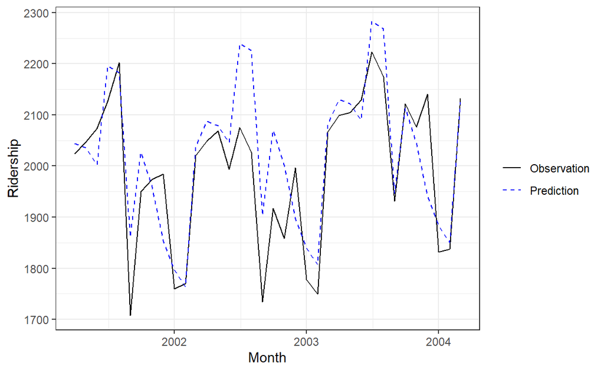

```
# Prediction Plot
ggplot(tail(Amtrak.data, n.test), aes(x = Month)) +
  geom_line(aes(y = Ridership, colour = "Observation", linetype = "Observation")) +
  geom_line(aes(y = stack.Pred.XGB, colour = "Prediction", linetype = "Prediction")) +
  scale_color_manual(name = "", values = c("Observation" = "black", "Prediction" = "blue")) +
  scale_linetype_manual("", values = c("Observation"= 1, "Prediction" = 2)) +
  theme_bw()
```

## **5. Stacking with GLM**

- 최종 모형에 Generalized Linear Model(GLM)을 사용함으로써, 개별 모형들의 예측 결과들에 가중치를 곱하여 더한 것을 최종 예측으로 생성한다.

### **모형 적합**

```
# Ref. https://github.com/zachmayer/caretEnsemble/blob/master/R/caretEnsemble.R

set.seed(100)
greedyEnsemble <- caretEnsemble(multi_mod, trControl = trainControl(method = "cv", number=5))
greedyEnsemble
```

```
A glm ensemble of 2 base models: parRF, xgbTree

Ensemble results:
Generalized Linear Model

38 samples
 2 predictor

No pre-processing
Resampling: Cross-Validated (5 fold)
Summary of sample sizes: 30, 31, 31, 30, 30
Resampling results:

  RMSE      Rsquared   MAE
  58.25038  0.8224663  45.03724
```

```
greedyEnsemble$ens_model$finalModel
```

```
Call:  NULL

Coefficients:
(Intercept)        parRF      xgbTree
   -8.46746      0.93423      0.02958

Degrees of Freedom: 37 Total (i.e. Null);  35 Residual
Null Deviance:      703200
Residual Deviance: 114700   AIC: 420.3
```

```
summary(greedyEnsemble)
```

```
The following models were ensembled: parRF, xgbTree
They were weighted:
-8.4675 0.9342 0.0296
The resulting RMSE is: 58.2504
The fit for each individual model on the RMSE is:
  method     RMSE RMSESD
   parRF 55.73908     NA
 xgbTree 58.30165     NA
```

### **예측**

```
# Final Prediction (Detrended + Trend)
stack.Pred.GLM <- predict(greedyEnsemble, Test.X) + trend.arima.pred$mean
```

### **Accuracy**

```
# Accuracy
acc_stack.GLM <- accuracy(c(stack.Pred.GLM), test.ts)
acc_stack.GLM
```

```
                ME    RMSE      MAE      MPE    MAPE      ACF1
Test set -19.94278 66.9187 44.73519 -1.09601 2.30595 0.5677311
         Theil's U
Test set  0.388657
```

### **예측 그래프**

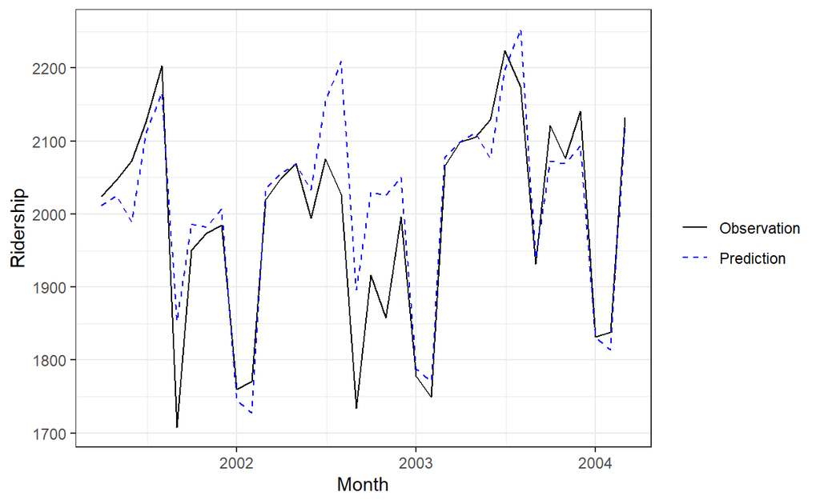

```
# Prediction Plot
ggplot(tail(Amtrak.data, n.test), aes(x = Month)) +
  geom_line(aes(y = Ridership, colour = "Observation", linetype = "Observation")) +
  geom_line(aes(y = stack.Pred.GLM, colour = "Prediction", linetype = "Prediction")) +
  scale_color_manual(name = "", values = c("Observation" = "black", "Prediction" = "blue")) +
  scale_linetype_manual("", values = c("Observation"= 1, "Prediction" = 2)) +
  theme_bw()
```

## **예측 비교2**

### **Line Plot**

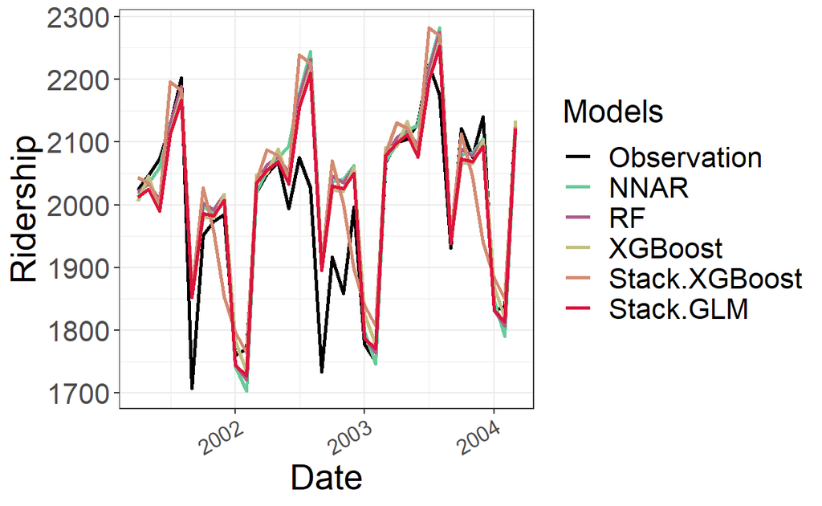

```
# 1. Line Plot
Pred.Data3 <- data.frame("Date" = tail(Amtrak.data$Month, n.test),
                         "Observation" = test.ts,
                         "NNAR" = NNAR.forecast,
                         "RF" = c(Pred.RF),
                         "XGBoost" = c(Pred.XGB),
                         "Stack.XGBoost" = c(stack.Pred.XGB),
                         "Stack.GLM" = c(stack.Pred.GLM))


Pred.Models3 <- reshape2::melt(Pred.Data3, id.vars="Date",
                               variable.name="Type",
                               value.name='y')

models2 <- unique(Pred.Models3$Type)

lcols <- c("#000000", "#66CC99", "#ae5d8b", "#c1c084", "#d38b72", "#dc143c", "#00498c", "#9999CC")

ggplot(Pred.Models3, aes(x=Date, y=y, group=Type)) +
  geom_line(aes(color=Type), size=1, linetype="solid") +
  labs(x="Date", y="Ridership") +                # y="log(Charging demand)"
  scale_color_manual(values = lcols, name = 'Models', labels = models2) +
  #scale_x_datetime(date_breaks= "24 hour", date_labels = paste("%Y- %m-%d %H", "h", sep="")) +  # %Y- %m-%d %H:%M:%S"
  theme_bw() +
  theme(axis.text.y=element_text(size=16),
        axis.title=element_text(size=20),
        axis.text.x=element_text(angle=30, hjust=1, size=12),
        legend.title = element_text(size=18),
        legend.text = element_text(size=16))
```

### **Scatter Plot**

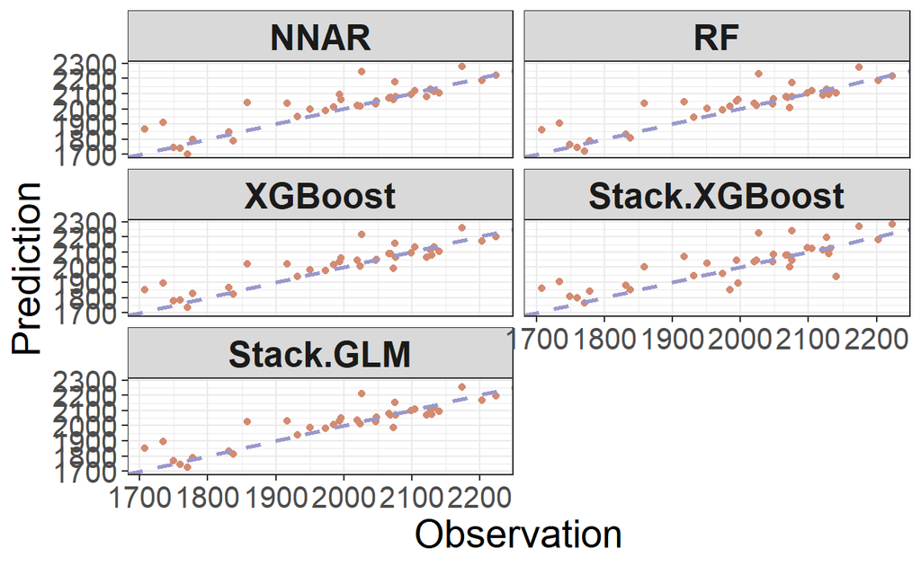

```
# 2. Scatter Plot
Pred.Models4 <- reshape2::melt(Pred.Data3[,-1], id.vars="Observation",
                               variable.name="Type",
                               value.name='Pred')

ggplot(Pred.Models4, aes(x=Observation, y=Pred)) +
  geom_point(color="#d38b72") +
  geom_abline(intercept = 0, slope = 1, size=1, colour="#9999CC", linetype="dashed") +
  facet_wrap( ~ Type, ncol=2) +
  labs(x="Observation", y="Prediction", color = "") +
  theme_bw() +
  theme(axis.title=element_text(size=20),
        axis.text=element_text(size=15),
        strip.text.x = element_text(size=18, face="bold"))
```